# Assessment

2025-10-31

## “Is there a relationship between antidepressant prescriptions and SIMD deprivation level in Scotland’s major cities (Glasgow, Edinburgh, Dundee and Aberdeen)?”

### Introduction

*Mental health* is a fundamental determinant of individual and societal well-being, closely intertwined with socioeconomic conditions. Economic pressures, such as living in resource-limited or relatively deprived communities, can potentially exacerbate mental health burdens. Regional disparities in public provision or the high cost of private care may lead individuals to rely primarily on pharmacological interventions rather than psychological therapies, reflecting limited access to specialized mental health services, which is a phenomenon that could be captured by exploring antidepressant prescription rates across different deprivation levels. In this analysis, the **relationship between SIMD deprivation levels and antidepressant prescribing patterns across Scotland’s four major cities, Edinburgh, Glasgow, Dundee, and Aberdeen**, is examined by linking **community prescription data by prescriber location from NHS Scotland**, published through the *Scottish Health and Social Care Open Data Service*, with **area-level deprivation scores** from the *Scottish Index of Multiple Deprivation (SIMD)*, and aming to provide insights into how mental health reflects and shapes socioeconomic and healthcare inequalities.

### Results

A general linear model was employed to estimate the overall effects of deprivation on antidepressant prescribing rates, including potential interactions between deprivation and city. By examining the model coefficients, the analysis investigates variation between groups by comparing each SIMD quintile to the reference quintile within each city, in order to assess how prescription differences between SIMD quintiles vary across cities. Macroscopically, the model evaluates whether deprivation, city, or their interaction exert an overall effect on antidepressant prescribing rates across all cities, using 2-way ANOVA. The null hypotheses are assumed that firstly, the antidepressant prescribing rates are equal across SIMD deprivation levels in Scotland’s major cities; secondly, the antidepressant prescribing rates are the same between cities; thirdly, there is no significant interaction between SIMD quintile and city. The 2-way ANOVA GLM provides a strong evidence that antidepressant prescribing rates significantly differs across SIMD deprivation levels (F = 7.8311, df = 4, p = $8.710 \times 10^{-6}$) and between the 4 major cities (F = 22.5658, df = 3, p = $3.173 \times 10^{-12}$). Contrarily, the pattern of change across SIMD quintiles is considered roughly similar in all cities (F = 1.2168, df = 12, p = 0.2758), although the overall prescribing rates can still be higher or lower in one city compared to another. Specifically, the highest antidepressant prescribing rates were observed in the most deprived areas (SIMD quintile 1; mean ± SE: 25496 ± 2430; 95% CI: 20697, 30295), whereas the lowest rates were found in the least deprived areas (SIMD quintile 5; mean ± SE: 11905 ± 3090; 95% CI: 5807, 18003). Although a general decreasing socioeconomic gradient might be expected, prescribing rates in the middle deprivation quintiles are not proportional to each other, where areas in quintile 4 possesses higher prescription rates (mean ± SE:22771 ± 3690; 95% CI: 15475, 30067), compared to areas in quintile 2 (mean ± SE:17534 ± 2440; 95% CI: 12706, 22362) and quintile 3 (mean ± SE: 15668 ± 2070; 11576, 19761).

### Discussion & Conclusion

This analysis highlights a close link between socioeconomic deprivation and mental health treatment burden. Prescribing rates for antidepressants varied across deprivation levels and between cities, pointing to the influence of socioeconomic inequalities on mental health. Although prescribing rates differed between cities, the overall pattern across SIMD deprivation quintiles was broadly similar, which may be attributed to variability within specific SIMD quintiles, including the presence of outliers, uneven distributions of data zones across deprivation levels, or wider interquartile ranges within certain cities at specific SIMD quintile levels. Taken together, these findings support the conclusion that SIMD deprivation level contributes to mental health burden. However, as deprivation captures multiple dimensions of reduced quality of life, such as income, employment, education, and health, future research could explore whether higher prescribing rates in more deprived areas primarily reflect a greater prevalence of mental health conditions, or whether they indicate increased reliance on pharmacological treatment due to limited access to non-pharmacological mental health support. Differences in antidepressant prescribing may therefore signal inequalities not only in mental health burden, but also in the availability and type of mental health care across socioeconomic contexts.

```r
links <- read_csv(here("file_links.csv")) %>%
  select(link) %>%
  pull()

joined_data_24 <- links %>%
  map(~ read_csv (.x) %>%
        select(GPPractice, BNFItemCode, NumberOfPaidItems, PaidDateMonth) %>%
        filter(str_detect(BNFItemCode, "^04030[1-4]"))) %>%
  list_rbind()
```

```r
GeoInfo <- read_csv(here("data", "GPPracticesOct.csv")) %>%
  select(PracticeCode, PracticeListSize, DataZone, GPCluster)

GeoInfo_24 <- joined_data_24 %>%
  left_join(GeoInfo, by = c("GPPractice" = "PracticeCode"))

SIMD <- read_csv(here("data", "SIMD2020v2.csv")) %>%
  select(DataZone, CA, SIMD2020V2Rank, SIMD2020V2CountryQuintile, SIMD2020V2CAQuintile)

CA <- read_csv(here("data", "CAarea.csv")) %>%
  select(CA, CAName) %>%
  filter(str_to_lower(CAName) %in% str_to_lower(c("city of Edinburgh", "Aberdeen city", "Glasgow city", "Dundee city")))

SIMD_CA <- left_join(CA, SIMD, by = c("CA" = "CA"))

Combined_data <- left_join(SIMD_CA, GeoInfo_24, by = c("DataZone" = "DataZone"))

Combined_data %>%
  filter(is.na(GPPractice)) %>%
  select(DataZone) %>%
  distinct()

Combined_data_clean <- Combined_data %>%
  filter(!is.na(GPPractice))

Population <- read_csv(here("data", "DataZonePopulationEstimate2021.csv")) %>%
  filter(Sex == "All", Year == "2022") %>%
  select(DataZone, TotalPopulation = AllAges)

Final_data <- Combined_data_clean %>%
  left_join(Population, by = c("DataZone" = "DataZone"))
```

```r
analysis_data <- Final_data %>%
  group_by(CAName, SIMD2020V2CountryQuintile, DataZone) %>%
  summarise(total_prescriptions = sum(NumberOfPaidItems, na.rm = TRUE),
    population = first(TotalPopulation),
    .groups = "drop") %>%
  mutate(prescriptions_per1000_perYear = ((total_prescriptions / population) * 1000) / 2) %>%
  filter(!is.na(DataZone))

mean_data <- analysis_data %>%
  group_by(CAName, SIMD2020V2CountryQuintile) %>%
  summarise(mean_rate = mean(prescriptions_per1000_perYear, na.rm = TRUE))
```

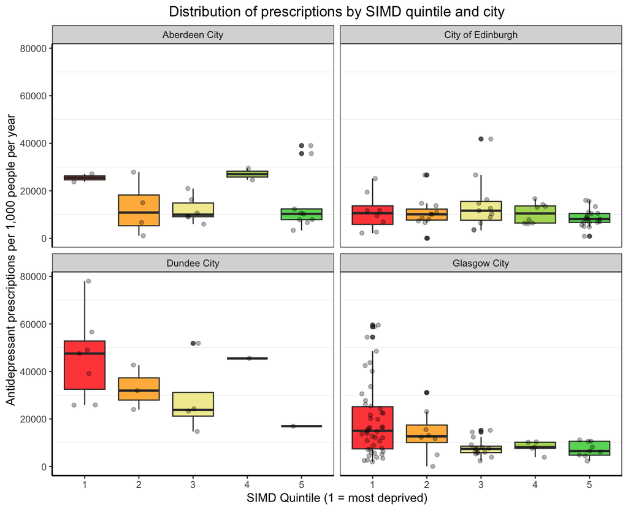

```r
ggplot(analysis_data,
       aes(x = factor(SIMD2020V2CountryQuintile), y = prescriptions_per1000_perYear, fill = factor(SIMD2020V2CountryQuintile))) +
  geom_boxplot(alpha = 0.8) +
  geom_jitter(width = 0.2, alpha = 0.3) +
  facet_wrap(~ CAName) +
  scale_fill_manual(values= c("1" = "red", "2" = "orange", "3" = "khaki2",
                              "4" = "yellowgreen", "5" = "limegreen"),
                    guide = "none") +
  labs(x = "SIMD Quintile (1 = most deprived)",
       y = "Antidepressant prescriptions per 1,000 people per year",
       title = "Distribution of prescriptions by SIMD quintile and city") +
  theme_bw() +
  theme(axis.line = element_line(size = 0.6, colour = "black"),
        panel.grid.major = element_blank(),
        plot.title = element_text(hjust = 0.5))
```

```r
stat_lm <- lm(prescriptions_per1000_perYear ~ factor(SIMD2020V2CountryQuintile) * CAName, data = analysis_data)
plot(stat_lm)
```

[output not shown]

```r
anova(stat_lm)
```

```
## Analysis of Variance Table
##
## Response: prescriptions_per1000_perYear
##                                           Df     Sum Sq    Mean Sq F value
## factor(SIMD2020V2CountryQuintile)          4 3.7475e+09  936879092  7.8311
## CAName                                     3 8.0990e+09 2699673362 22.5658
## factor(SIMD2020V2CountryQuintile):CAName  12 1.7468e+09  145567707  1.2168
## Residuals                                159 1.9022e+10  119635856
##                                             Pr(>F)
## factor(SIMD2020V2CountryQuintile)        8.710e-06 ***
## CAName                                   3.173e-12 ***
## factor(SIMD2020V2CountryQuintile):CAName    0.2758
## Residuals
## ---
## Signif. codes:  0 '***' 0.001 '**' 0.01 '*' 0.05 '.' 0.1 ' ' 1
```

```r
stat_emm <- emmeans(stat_lm, ~SIMD2020V2CountryQuintile)
stat_emm
```

```
##  SIMD2020V2CountryQuintile emmean   SE  df lower.CL upper.CL
##                          1  25496 2430 159    20697    30295
##                          2  17534 2440 159    12706    22362
##                          3  15668 2070 159    11576    19761
##                          4  22771 3690 159    15475    30067
##                          5  11905 3090 159     5807    18003
##
## Results are averaged over the levels of: CAName
## Confidence level used: 0.95
```

```r
summary(stat_lm)
```

[output not shown]

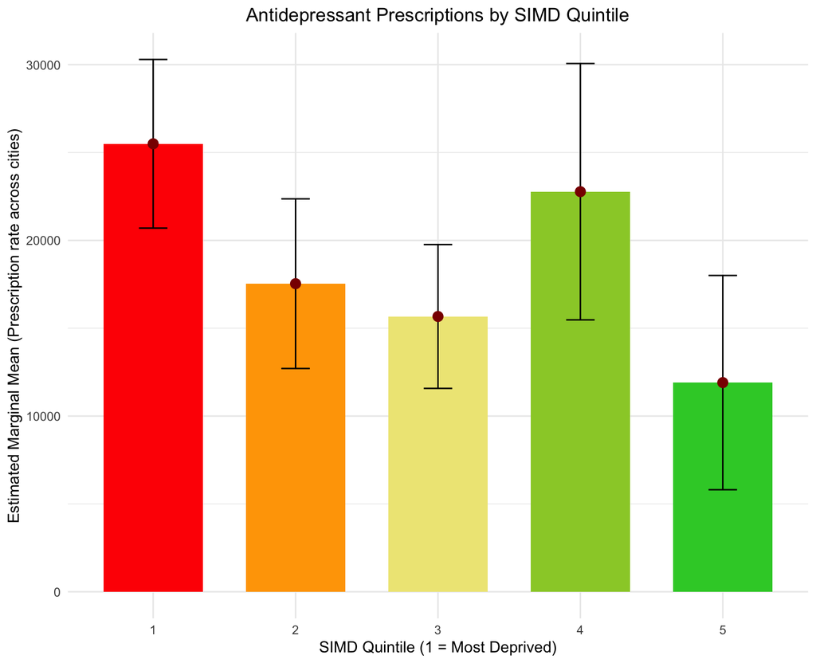

```r
stat_emm_plot <- as.data.frame(stat_emm)

ggplot(stat_emm_plot, aes(x = factor(SIMD2020V2CountryQuintile), y = emmean, fill = factor(SIMD2020V2CountryQuintile))) +
  geom_col(width = 0.7) +
  geom_errorbar(aes(ymin = lower.CL, ymax = upper.CL), width = 0.2, color = "black") +
  geom_point(size = 3, color = "darkred") +
  scale_fill_manual(
    values = c("1" = "red", "2" = "orange", "3" = "khaki2", "4" = "yellowgreen", "5" = "limegreen"), guide = "none") +
  labs(title = "Antidepressant Prescriptions by SIMD Quintile",
       x = "SIMD Quintile (1 = Most Deprived)",
       y = "Estimated Marginal Mean (Prescription rate across cities)") +
  theme_minimal() +
  theme(plot.title = element_text(hjust = 0.5))
```

```r
gt_table <- stat_emm_plot %>%
  gt() %>%
  tab_header(title = "Estimated Marginal Means of Antidepressant Prescriptions by SIMD Quintile across 4 Major Cities", subtitle = "Data obtained from Public Health Scotland") %>%
  cols_label(SIMD2020V2CountryQuintile = "SIMD Quintile (Country-level)", emmean = "Emmeans", SE = "Standard Error", df = "Degree of Freedom", lower.CL = "Lower 95% CI", upper.CL = "Upper 95% CI") %>%
  cols_align(align = "center", columns = everything()) %>%
  fmt_number(columns = vars(emmean, SE, lower.CL, upper.CL), decimals = 1) %>%
  tab_style(style = cell_fill(color = "lightgrey"), locations = cells_column_labels(everything())) %>%
  tab_source_note(source_note = "N.B. Estimated marginal means (emmeans) calculated as prescription rate per 1,000 population per year, averaged across cities.")
gt_table
```

Estimated Marginal Means of Antidepressant Prescriptions by SIMD Quintile across 4 Major Cities

Data obtained from Public Health Scotland

| SIMD Quintile (Country-level) | Emmeans | Standard Error | Degree of Freedom | Lower 95% CI | Upper 95% CI |
| --- | --- | --- | --- | --- | --- |
| 1 | 25,496.0 | 2,429.8 | 159 | 20,697.1 | 30,294.8 |
| 2 | 17,534.4 | 2,444.6 | 159 | 12,706.3 | 22,362.5 |
| 3 | 15,668.2 | 2,072.1 | 159 | 11,575.7 | 19,760.6 |
| 4 | 22,770.8 | 3,694.0 | 159 | 15,475.1 | 30,066.5 |
| 5 | 11,905.0 | 3,087.5 | 159 | 5,807.3 | 18,002.7 |

N.B. Estimated marginal means (emmeans) calculated as prescription rate per 1,000 population per year, averaged across cities.